# Побудова моделі

## Мета

Ознайомитись з різновидами регресійних моделей. Після завершення цієї лабораторної роботи ви зможете:

- Будувати регресійні моделі кількох видів
- Оцінювати якість моделі візуально
- Оцінювати якість моделі за допомогою числових мір, без використання тестової вибірки
- Виконувати прогнозування відгуку, використовуючи побудовану модель
1. Скачати дані із файлу "clean_data2.csv" (Data2.csv з виправленими помилками та заповненими пропусками). Записати дані у dataframe. В попередній роботі ви визначили ознаки, що можуть бути предикторами для 'CO2 emission'. Побудуйте моделі лінійної регресії для кожного з цих предикторів.
2. Побудуйте модель множинної лінійної регресії для всіх доречних предикторів разом.
3. Побудуйте кілька поліноміальних моделей другого порядку.
4. Побудуйте візуалізації для оцінки всіх моделей.
5. Порахуйте значення R^2 та MSE для оцінки якості кожної моделі. Оберіть найкращу модель.

Скачати дані із файлу ['clean_data2.csv'](https://drive.google.com/file/d/1wSj5SKRPKOjNPP2cyqaNpxRCinKEmJkO/view?usp=drive_link) (Data2.csv з виправленими помилками та заповненими пропусками). Записати дані у dataframe.

В попередній роботі ви визначили ознаки, що можуть бути предикторами для 'CO2 emission'. Побудуйте моделі лінійної регресії для кожного з цих предикторів.

Зчитую дані з файлу у датафрейм

```python
import pandas as pd
import seaborn as sns
import matplotlib.pyplot as plt

DATA_PATH = 'data/clean_data.csv'

df = pd.read_csv(DATA_PATH, sep=';', encoding='cp1252')

df[['country_name', 'region']] =  df[['country_name', 'region']].astype('string')
df.dtypes
```

```
country_name          string[python]
region                string[python]
gdp_per_capita                 int64
population                     int64
co2_emission                 float64
area                         float64
population_density           float64
dtype: object
```

З попередньої роботи знаємо, що хорошими показниками для 'CO2 emission' можуть бути:

- population
- area

Розробимо моделі, використовуючи ці ознаки як змінні-предиктори.

Створюю об’єкт лінійної регресії та навчаю першу модель

```python
from sklearn.linear_model import  LinearRegression

lm = LinearRegression()
```

Знаходжу коефіцієнти моделі

```python
x = df[['population']]
y = df[['co2_emission']]
```

Будую лінійну модель та знаходжу прогноз

```python
lm.fit(x, y)
y_hat1 = lm.predict(x)

y_hat1[0:5]
```

```
array([[157961.46006296],
       [  3792.80063443],
       [186825.7960797 ],
       [ -9784.64632044],
       [129618.38309565]])
```

Знаходжу коефіцієнти моделі

```python
# a
lm.intercept_
```

```
array([-10159.54669921])
```

```python
# b
lm.coef_
```

```
array([[0.00485113]])
```

Отримали кінцеву лінійну модель зі структурою: $$ Yhat1 = a + b X $$

Підставляючи фактичні значення, маємо:

```python
# Напишіть рівняння моделі, виконувати не потрібно
# co2_emission = -10159.54669921 + 0.00485113 * population
```

Створюю об’єкт лінійної регресії та навчаю другу модель

```python
# Напишіть ваш код нижче та натисніть Shift+Enter для виконання
lm2 = LinearRegression()
lm2

x = df[['area']]
y = df[['co2_emission']]

lm2.fit(x, y)

y_hat2 = lm2.predict(x)
y_hat2[0:5]
```

```
array([[164572.96099962],
       [  1535.03630769],
       [616212.90787019],
       [ -5852.62373668],
       [319703.37262426]])
```

Знаходжу коефіцієнти моделі

```python
# a
lm2.intercept_
```

```
array([-5975.40309385])
```

```python
# b
lm2.coef_
```

```
array([[0.26123267]])
```

Отримали кінцеву лінійну модель зі структурою: $$ Yhat2 = a + b X $$

Підставляючи фактичні значення, маємо:

```python
# Напишіть рівняння моделі, виконувати не потрібно
# co2_emission = -5975.40309385 + 0.26123267 * area
```

Побудуйте модель множинної лінійної регресії для всіх доречних предикторів разом.

Створюю об’єкт лінійної регресії та навчаю множинну лінійну модель із структурою $$ Yhat3 = a + b_1 X_1 + b_2 X_2 $$

```python
# Напишіть ваш код нижче та натисніть Shift+Enter для виконання
lm3 = LinearRegression()
lm3
```

```
LinearRegression()
```

Знаходжу коефіцієнти моделі

```python
# Напишіть ваш код нижче та натисніть Shift+Enter для виконання
z = df[['population', 'area']]
```

```python
# Будую модель
lm3.fit(z, y)

# a
print(lm3.intercept_)

# b
print(lm3.coef_)
```

```
[-64602.4231751]
[[0.00408248 0.12553168]]
```

Підставляючи фактичні значення, маємо:

```python
# Напишіть рівняння моделі, виконувати не потрібно
# co2_emission = -64602.4231751 + 0.00408248 * population + 0.12553168 * area
```

Побудуйте кілька поліноміальних моделей другого порядку.

Створюю об’єкт поліноміальної регресії та навчаю поліноміальну модель із структурою $$ Yhat4 = a + b_1 X_1 + b_2 X_1^2 $$

Знаходжу коефіцієнти моделі

```python
# Напишіть ваш код нижче та натисніть Shift+Enter для виконання
import numpy as np

y = df['co2_emission']
x1 = df['population']

y_hat4 = np.polyfit(x1, y, 2)

pm = np.poly1d(y_hat4)
print(pm)
```

```
            2
-4.064e-13 x + 0.005361 x - 2.035e+04
```

```python
# Знаходжу коефіцієнти моделі

print(f'''Коефіцієнти моделі:
Коефіцієнт a: {y_hat4[2]}
Коефіцієнт b1: {y_hat4[1]}
Коефіцієнт b2: {y_hat4[0]}
      ''')
```

```
Коефіцієнти моделі:
Коефіцієнт a: -20353.248819624074
Коефіцієнт b1: 0.005361434280573773
Коефіцієнт b2: -4.0635020747943424e-13
```

co2_emission = -20353.248819624074 + 0.005361434280573773 * population + -4.0635020747943424e-13 * population ^ 2

Створюю об’єкт поліноміальної регресії та навчаю поліноміальну модель із структурою $$ Yhat5 = a + b_1 X_2 + b_2 X_2^2 $$

Знаходжу коефіцієнти моделі

```python
# Напишіть ваш код нижче та натисніть Shift+Enter для виконання

x2 = df['area']
y_hat5 = np.polyfit(x2, y, 2)

pm2 = np.poly1d(y_hat5)
print(pm2)
```

```
            2
-1.542e-08 x + 0.4451 x - 6.59e+04
```

```python
# Знаходжу коефіцієнти моделі

print(f'''Коефіцієнти моделі:
Коефіцієнт a: {y_hat5[2]}
Коефіцієнт b1: {y_hat5[1]}
Коефіцієнт b2: {y_hat5[0]}
      ''')
```

```
Коефіцієнти моделі:
Коефіцієнт a: -65899.66785279519
Коефіцієнт b1: 0.4451438292736714
Коефіцієнт b2: -1.5417934961341924e-08
```

co2_emission = -65899.66785279519 + 0.4451438292736714 * area + -1.5417934961341924e-08 * area ^ 2

Створюю об’єкт поліноміальної регресії та навчаю поліноміальну модель із структурою $$ Yhat6 = a + b_1 X_1 + b_2 X_2 + b_3 X_1 X_2 + b_4 X_1^2 + b_5 X_2^2 $$

Знаходжу коефіцієнти моделі

```python
# Напишіть ваш код нижче та натисніть Shift+Enter для виконання
from sklearn.preprocessing import PolynomialFeatures

pf = PolynomialFeatures(degree=2)
pf
```

```
PolynomialFeatures()
```

```python
z = df[['population', 'area']]

z_pr = pf.fit_transform(z)
z.shape
```

```
(205, 2)
```

205 спостережень та 2 ознаки

```python
z_pr.shape
```

```
(205, 6)
```

Після трансформації отримали 205 спостережень та 6 ознак

```python
y_hat6 = LinearRegression()
y_hat6.fit(z_pr, y)
```

```
LinearRegression()
```

```python
a = y_hat6.intercept_
bs = y_hat6.coef_

print(f"Коефіцієнт a: {a}")

for b in range(1, len(bs)):
    print(f"Коефіцієнт b{b}: {bs[b]}")
```

```
Коефіцієнт a: 1438.297851839161
Коефіцієнт b1: 0.0023704702945945956
Коефіцієнт b2: 0.02648874492661869
Коефіцієнт b3: -3.177693145334876e-12
Коефіцієнт b4: 1.0182694284710373e-09
Коефіцієнт b5: -4.406939929454079e-09
```

co2_emissions = 1438.297851839161 + 0.0023704702945945956 * population + 0.02648874492661869 * area + -3.177693145334876e-12 * population * area + 1.0182694284710373e-09 * population^2 + -4.406939929454079e-09 * area^2

Побудуйте візуалізації для оцінки всіх моделей.

Для простої лінійної регресії чудовим способом візуалізації відповідності моделі є використання графіків регресії. Цей графік покаже комбінацію розсіяних точок даних (діаграма розсіювання, scatterplot) та підігнану лінію лінійної регресії, що проходить через дані.

Таким способом візуалізую перші моделі.

```
(0.0, 12106615.861098735)
```

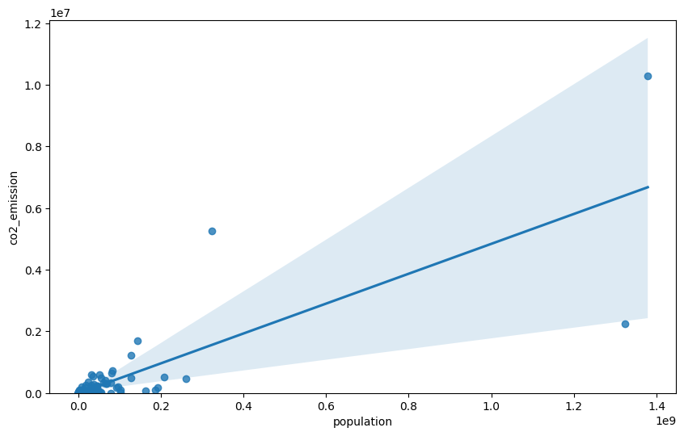

```python
import seaborn as sns
%matplotlib inline
# Напишіть ваш код нижче та натисніть Shift+Enter для виконання

plt.figure(figsize=(10, 6))
sns.regplot(x='population', y='co2_emission', data=df)
plt.ylim(0,)
```

Оскільки кут нахилу лінійної регресії позитивний, то звʼязок між чисельністю населення та обсягом викидів вуглекислого газу позитивний.

```
(0.0, 10813024.893512102)
```

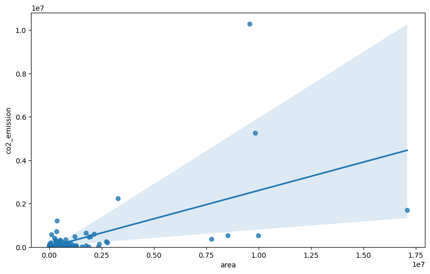

```python
plt.figure(figsize=(10, 6))
sns.regplot(x='area', y='co2_emission', data=df)
plt.ylim(0,)
```

Оскільки кут нахилу лінійної регресії позитивний, то звʼязок між площею та обсягом викидів вуглекислого газу позитивний.

Для візуалізації дисперсії даних використаю діаграми залишків - по ній зможу прийняти рішення про необхідність ускладнення моделі.

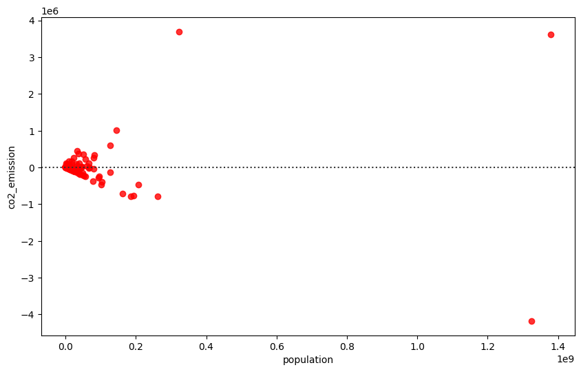

```python
# Напишіть ваш код нижче та натисніть Shift+Enter для виконання
plt.figure(figsize=(10, 6))
sns.residplot(x=df['population'], y=df['co2_emission'], color='red')
plt.show()
```

Оскільки на графіку залишків розподіл не є випадковий відносно осі абсцис, для аналізу краще використовувати нелінійну модель

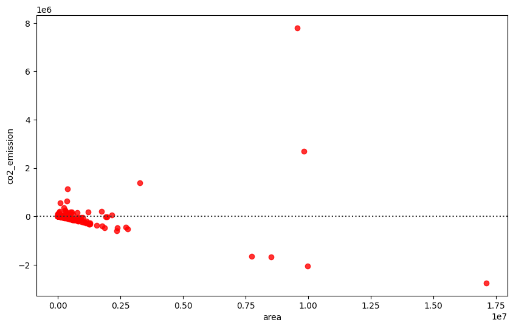

```python
# Напишіть ваш код нижче та натисніть Shift+Enter для виконання
plt.figure(figsize=(10, 6))
sns.residplot(x=df['area'], y=df['co2_emission'], color='red')
plt.show()
```

Оскільки на графіку залишків розподіл не є випадковий відносно осі абсцис, для аналізу краще використовувати нелінійну модель

Для візуалізації моделі множинної лінійної регресії використаю діаграму розподілу.

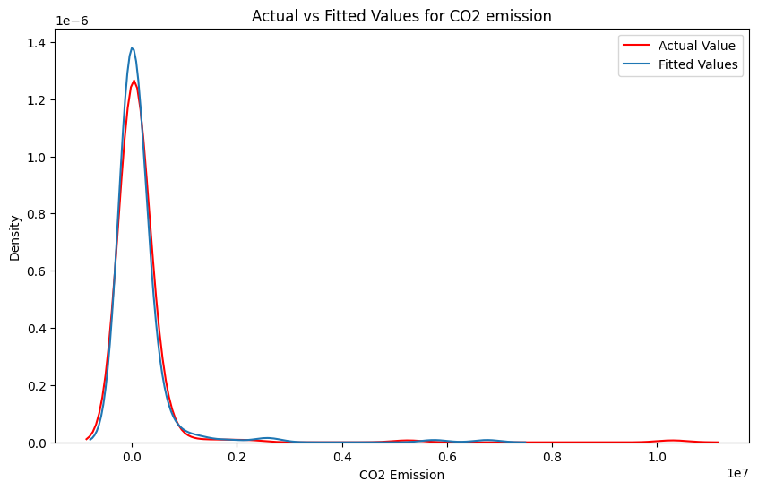

```python
plt.figure(figsize=(10, 6))
ax1 = plt.gca()

sns.kdeplot(df['co2_emission'], color="r", label="Actual Value", ax=ax1)

y_hat = lm3.predict(df[['population', 'area']])
sns.kdeplot(y_hat, color="b", label="Fitted Values", ax=ax1)

# Додаткове оформлення
plt.title("Actual vs Fitted Values for CO2 emission")
plt.xlabel("CO2 Emission")
plt.ylabel("Density")
plt.legend()
plt.show()
plt.close()
```

Підібрані значення та фактичні майже накладаються, тому вони досить близькі.

```python
# Напишіть ваш код нижче та натисніть Shift+Enter для виконання
print(np.poly1d(y_hat4))
```

```
            2
-4.064e-13 x + 0.005361 x - 2.035e+04
```

```python
# Напишіть ваш код нижче та натисніть Shift+Enter для виконання
print(np.poly1d(y_hat5))
```

```
            2
-1.542e-08 x + 0.4451 x - 6.59e+04
```

Для візуалізації поліноміальних моделей з кількома предикторами використаю діаграму розподілу або діаграму залишків

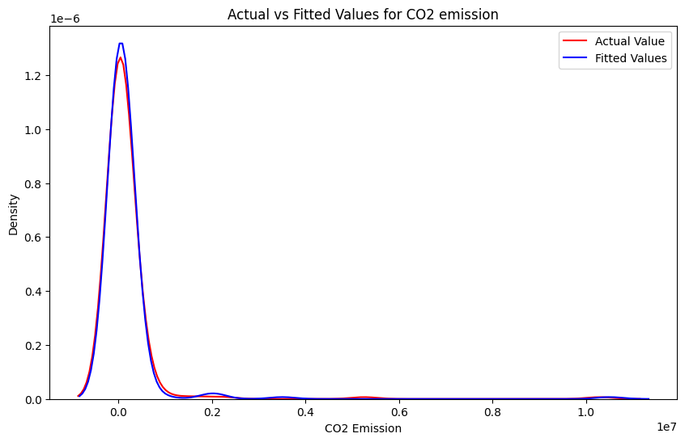

```python
# Напишіть ваш код нижче та натисніть Shift+Enter для виконання
plt.figure(figsize=(10, 6))
ax1 = plt.gca()

sns.kdeplot(df['co2_emission'], color="r", label="Actual Value", ax=ax1)
y_hat = y_hat6.predict(z_pr)
sns.kdeplot(y_hat, color="b", label="Fitted Values", ax=ax1)

# Додаткове оформлення
plt.title("Actual vs Fitted Values for CO2 emission")
plt.xlabel("CO2 Emission")
plt.ylabel("Density")
plt.legend()
plt.show()
plt.close()
```

Порахуйте значення R^2 та MSE для оцінки якості кожної моделі. Оберіть найкращу модель.

Значення R^2 отримую безпосередньо з моделі `.score(X, Y)`, а для розрахунку MSE спочатку формую прогнозовані значення `.predict(X)` і порівнюю їх з фактичними

Модель 1: $$ Yhat1 = a + b X $$

```python
# Напишіть ваш код нижче та натисніть Shift+Enter для виконання
x1 = df[['population']]
y = df[['co2_emission']]

print('The R-square is: ', lm.score(x1, y))
```

```
The R-square is:  0.6461006246187183
```

65% варіації рівня викідів вуглекислого газу пояснюється Yhat1

```python
yhat1 = lm.predict(x1)
print('Output:' , yhat1[0:5])
```

```
Output: [[157961.46006296]
 [  3792.80063443]
 [186825.7960797 ]
 [ -9784.64632044]
 [129618.38309565]]
```

```python
from sklearn.metrics import mean_squared_error, mean_absolute_error, r2_score

# Calculate the mean squared error
mse = mean_squared_error(y, yhat1)
print('The mean squared error is: ', mse)

# Calculate the mean absolute error
mae = mean_absolute_error(y, yhat1)
print('The mean absolute error is: ', mae)

# Calculate the R-squared value
r2 = r2_score(y, yhat1)
print('The R-squared value is: ', r2)
```

```
The mean squared error is:  244683403840.77405
The mean absolute error is:  132907.01112251525
The R-squared value is:  0.6461006246187183
```

Модель 2: $$ Yhat2 = a + b X $$

```python
# Напишіть ваш код нижче та натисніть Shift+Enter для виконання
x2 = df[['area']]

print('The R-square is: ', lm2.score(x2, y))
```

```
The R-square is:  0.3451331940921192
```

35% варіації рівня викідів вуглекислого газу пояснюється Yhat2

```python
yhat2 = lm2.predict(x2)
print('Output:' , yhat2[0:5])
```

```
Output: [[164572.96099962]
 [  1535.03630769]
 [616212.90787019]
 [ -5852.62373668]
 [319703.37262426]]
```

```python
# Calculate the mean squared error
mse = mean_squared_error(y, yhat2)
print('The mean squared error is: ', mse)

# Calculate the mean absolute error
mae = mean_absolute_error(y, yhat2)
print('The mean absolute error is: ', mae)

# Calculate the R-squared value
r2 = r2_score(y, yhat2)
print('The R-squared value is: ', r2)
```

```
The mean squared error is:  452770053519.4301
The mean absolute error is:  178668.3942274042
The R-squared value is:  0.3451331940921192
```

Модель 3: $$ Yhat3 = a + b_1 X_1 + b_2 X_2 $$

```python
# Напишіть ваш код нижче та натисніть Shift+Enter для виконання
z = df[['population', 'area']]

print('The R-square is: ', lm3.score(z, y))
```

```
The R-square is:  0.7095760957246346
```

71% варіації рівня викідів вуглекислого газу пояснюється Yhat3

```python
y_predict_multiple = lm3.predict(z)
print('Output:' , y_predict_multiple[0:5])
```

```
Output: [[158834.74031486]
 [-49251.76306514]
 [400154.78456147]
 [-64227.92516148]
 [209528.30180787]]
```

```python
# Calculate the mean squared error
mse = mean_squared_error(y, y_predict_multiple)
print('The mean squared error is: ', mse)
# Calculate the mean absolute error
mae = mean_absolute_error(y, y_predict_multiple)
print('The mean absolute error is: ', mae)
# Calculate the R-squared value
r2 = r2_score(y, y_predict_multiple)
print('The R-squared value is: ', r2)
```

```
The mean squared error is:  200796933812.79166
The mean absolute error is:  161276.78453860086
The R-squared value is:  0.7095760957246346
```

Модель 4: $$ Yhat4 = a + b_1 X_1 + b_2 X_1^2 $$

```python
p = np.poly1d(y_hat4)

r_squared = r2_score(y, p(x1))

print('The R-square is: ', r_squared)
```

```
The R-square is:  0.646669597790839
```

65% варіації рівня викідів вуглекислого газу пояснюється Yhat4

```python
# Calculate the mean squared error
mse = mean_squared_error(y, p(x1))
print('The mean squared error is: ', mse)
# Calculate the mean absolute error
mae = mean_absolute_error(y, p(x1))
print('The mean absolute error is: ', mae)
# Calculate the R-squared value
r2 = r2_score(y, p(x1))
print('The R-squared value is: ', r2)
```

```
The mean squared error is:  244290020008.7213
The mean absolute error is:  138798.7570131029
The R-squared value is:  0.646669597790839
```

Модель 5: $$ Yhat5 = a + b_1 X_2 + b_2 X_2^2 $$

```python
# Напишіть ваш код нижче та натисніть Shift+Enter для виконання
p = np.poly1d(y_hat5)
r_squared = r2_score(y, p(x2))
print('The R-square is: ', r_squared)
```

```
The R-square is:  0.3740137141949029
```

37% варіації рівня викідів вуглекислого газу пояснюється Yhat5

```python
# Calculate the mean squared error
mse = mean_squared_error(y, p(x2))
print('The mean squared error is: ', mse)
# Calculate the mean absolute error
mae = mean_absolute_error(y, p(x2))
print('The mean absolute error is: ', mae)
# Calculate the R-squared value
r2 = r2_score(y, p(x2))
print('The R-squared value is: ', r2)
```

```
The mean squared error is:  432802276080.3553
The mean absolute error is:  220627.8246147237
The R-squared value is:  0.3740137141949029
```

Модель 6: $$ Yhat6 = a + b_1 X_1 + b_2 X_2 + b_3 X_1 X_2 + b_4 X_1^2 + b_5 X_2^2 $$

```python
# Напишіть ваш код нижче та натисніть Shift+Enter для виконання
r_squared = y_hat6.score(z_pr, y)
print('The R-square is: ', r_squared)
```

```
The R-square is:  0.938000210835021
```

```python
# Calculate the mean squared error
mse = mean_squared_error(y, y_hat6.predict(z_pr))
print('The mean squared error is: ', mse)
# Calculate the mean absolute error
mae = mean_absolute_error(y, y_hat6.predict(z_pr))
print('The mean absolute error is: ', mae)
# Calculate the R-squared value
r2 = r2_score(y, y_hat6.predict(z_pr))
print('The R-squared value is: ', r2)
```

```
The mean squared error is:  42866194476.758514
The mean absolute error is:  78155.41380847397
The R-squared value is:  0.938000210835021
```

#### Висновок

Порівнюючи всі моделі, роблю висновок, що **модель y_hat6 є найкращою моделлю** для прогнозування 'CO2 emission' на основі нашого набору даних.

Побудуйте та оцініть кілька поліноміальних моделей різних порядків.

1. Побудуйте кілька поліноміальних моделей різних порядків.
2. Побудуйте візуалізації для оцінки всіх моделей (зручно розміщувати всі моделі на одному графіку для обрання найкращої).
3. Порахуйте значення R^2 та MSE для оцінки якості кожної моделі (теж доцільно побудувати графік залежності R^2 або MSE від порядку поліному моделі).
4. Оберіть найкращу модель, висновок обгрунтуйте.

```python
from sklearn.metrics import mean_squared_error, r2_score

# Для зручності обчислення
x = df['population']
y = df['co2_emission']

# Порядки поліномів, які будемо тестувати
degrees = [1, 2, 3, 4, 5]

# Словники для збереження метрик
models = {}
mse_values = []
r2_values = []

# Побудова моделей
for d in degrees:
    coeffs = np.polyfit(x, y, d)
    model = np.poly1d(coeffs)
    y_pred = model(x)

    mse = mean_squared_error(y, y_pred)
    r2 = r2_score(y, y_pred)

    models[d] = model
    mse_values.append(mse)
    r2_values.append(r2)

    print(f"Порядок: {d}")
    print(f"R² = {r2:.4f}, MSE = {mse:.2f}")
    print(model, "\n")
```

```
Порядок: 1
R² = 0.6461, MSE = 244683403840.77

0.004851 x - 1.016e+04

Порядок: 2
R² = 0.6467, MSE = 244290020008.72
            2
-4.064e-13 x + 0.005361 x - 2.035e+04

Порядок: 3
R² = 0.6731, MSE = 225999777902.84
           3             2
2.085e-20 x - 3.278e-11 x + 0.01103 x - 8.091e+04

Порядок: 4
R² = 0.8711, MSE = 89148889556.12
           4             3             2
9.925e-29 x - 1.991e-19 x + 9.474e-11 x - 0.004974 x + 6.646e+04

Порядок: 5
R² = 0.9359, MSE = 44299321776.31
          5             4             3             2
4.06e-37 x - 1.142e-27 x + 9.445e-19 x - 2.009e-10 x + 0.01418 x - 5.072e+04
```

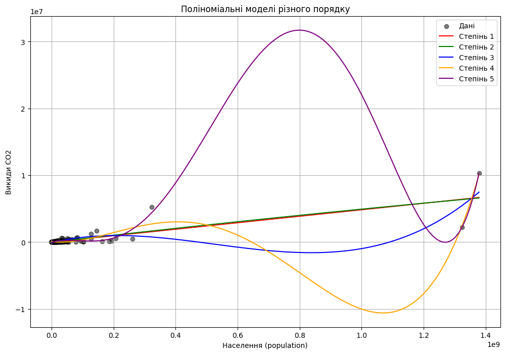

```python
plt.figure(figsize=(12, 8))
plt.scatter(x, y, color='black', label='Дані', alpha=0.5)

x_vals = np.linspace(x.min(), x.max(), 500)

# Кольори для графіків
colors = ['r', 'g', 'b', 'orange', 'purple']

for i, d in enumerate(degrees):
    y_vals = models[d](x_vals)
    plt.plot(x_vals, y_vals, label=f'Степінь {d}', color=colors[i])

plt.xlabel("Населення (population)")
plt.ylabel("Викиди CO2")
plt.title("Поліноміальні моделі різного порядку")
plt.legend()
plt.grid(True)
plt.show()
```

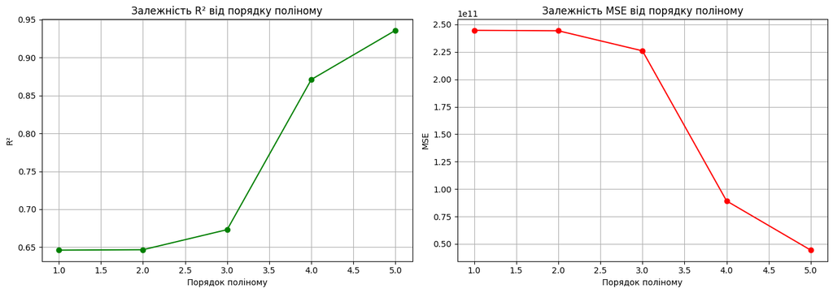

```python
plt.figure(figsize=(14, 5))

# R² графік
plt.subplot(1, 2, 1)
plt.plot(degrees, r2_values, marker='o', linestyle='-', color='green')
plt.title('Залежність R² від порядку поліному')
plt.xlabel('Порядок поліному')
plt.ylabel('R²')
plt.grid(True)

# MSE графік
plt.subplot(1, 2, 2)
plt.plot(degrees, mse_values, marker='o', linestyle='-', color='red')
plt.title('Залежність MSE від порядку поліному')
plt.xlabel('Порядок поліному')
plt.ylabel('MSE')
plt.grid(True)

plt.tight_layout()
plt.show()
```

```python
best_degree = degrees[np.argmax(r2_values)]
print(f"Найкраща модель — поліном порядку {best_degree}")
```

```
Найкраща модель — поліном порядку 5
```

## Виконав студент групи ІП-33 Соколов Олександр